# WeRateDogs Analysis using Twitter data

[figure not shown]

[@WeRateDogs](https://twitter.com/dog_rates) is a twitter account that provides "professional dog ratings" since November 2015 boasting 9.3 million followers and a lot of media attention. The project at hand focuses on gathering the @WeRateDogs archive data, favorites and retweets count annd image predictions up until August 2017. The information collected would provide analytical insights into the various activities on the [@WeRateDogs](https://twitter.com/dog_rates) account.

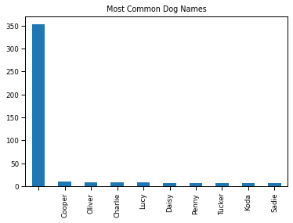

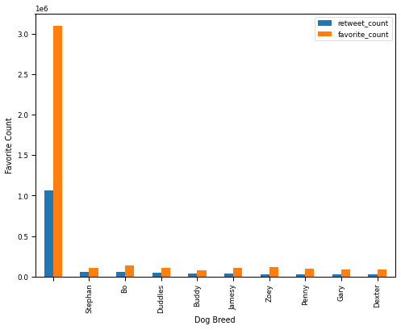

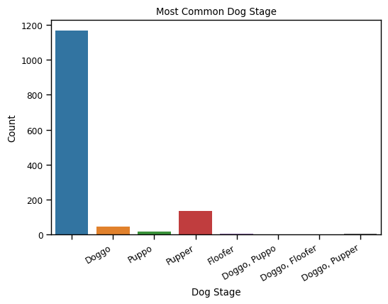

When these empty name strings in the `name` and `dog _stage` columns of the dataframe are not included in the analyses, then we get a slightly different picture from the cells that are not empty.

The most and least common dog names were documented by obtaining the top 10 value_counts for each of the dog names.

[output not shown]

The most popular dog names were based on the retweets and favorite counts.

[output not shown]

Most of the featured dogs were categorized as Pupper, based on the @WeRateDogs dogtionary. The Pupper dog stage was also the most favourited dog stage (who doesnt love a good Pupper?!!) and Doggo was the most retweeted stage. There were dogs alloted two dog stages such as *Doggo, Pupper*, *Doggo, Floofer*, *Doggo, Puppo*, I reckon these display double dose of '*duteness*' (**d**og-c**uteness**).....1000/10!!!

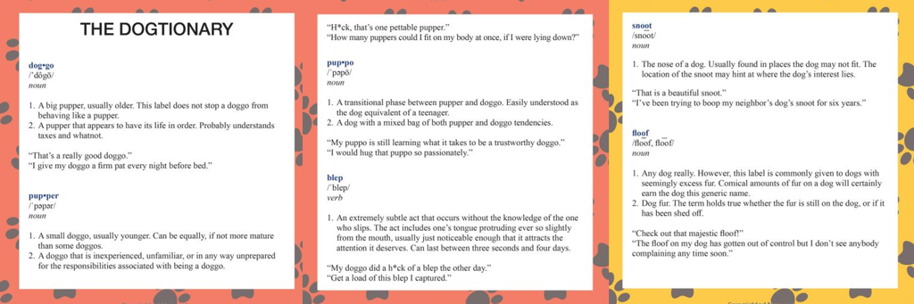

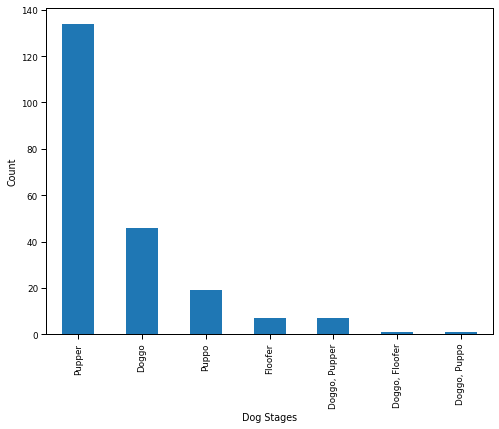

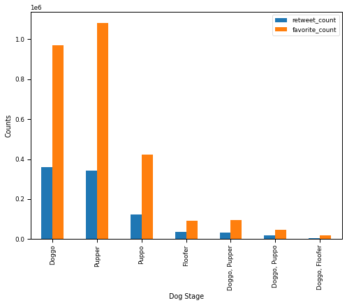

The dog breeds were based on a neural network breed prediction of the dog images, collected from the [@WeRateDogs](https://twitter.com/dog_rates). So what dog breed were most popular based on the favorite and retweets? (I asked the same question. Lol!). The beautiful golden haired and very playful **Golden retriever** was the most popular dog breed, along with the **Pembroke, Labrador retriever, Chihuahua** (no surpise here!) and **French bulldog**.

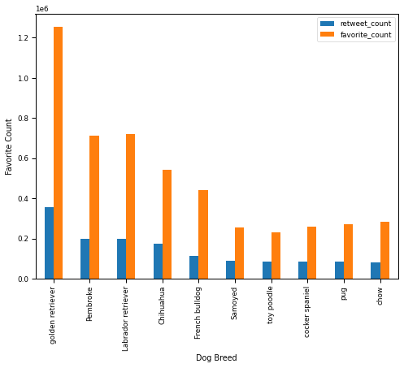

The [@WeRateDogs](https://twitter.com/dog_rates) twitter is a 'happy hormone' booster for sure and the analyses provide possible insights into the names of that are most favoured by '*dog parents*' and the breeds that are most favoured by everyone. @WeRateDogs also provides ratings for the featured dogs, and these information is not considered in [this analysis](https://github.com/), but would be interesting to explore in future analysis.

In conclusion, adopt a dog and improve the quality of life!